# P10_Détectez_des_faux_billets

Shibin_YANG

# 1 - Importation des données

```r
data <- read.table("Desktop/Openclassrooms/P10_Shibin_YANG/billets.csv", sep = ";", dec = ".", header=TRUE)
data [1:5, ]
```

```
##   is_genuine diagonal height_left height_right margin_low margin_up length
## 1       True   171.81      104.86       104.95       4.52      2.89 112.83
## 2       True   171.46      103.36       103.66       3.77      2.99 113.09
## 3       True   172.69      104.48       103.50       4.40      2.94 113.16
## 4       True   171.36      103.91       103.94       3.62      3.01 113.51
## 5       True   171.73      104.28       103.46       4.04      3.48 112.54
```

```r
summary(data)
```

```
##   is_genuine           diagonal      height_left     height_right
##  Length:1500        Min.   :171.0   Min.   :103.1   Min.   :102.8
##  Class :character   1st Qu.:171.8   1st Qu.:103.8   1st Qu.:103.7
##  Mode  :character   Median :172.0   Median :104.0   Median :103.9
##                     Mean   :172.0   Mean   :104.0   Mean   :103.9
##                     3rd Qu.:172.2   3rd Qu.:104.2   3rd Qu.:104.2
##                     Max.   :173.0   Max.   :104.9   Max.   :105.0
##
##    margin_low      margin_up         length
##  Min.   :2.980   Min.   :2.270   Min.   :109.5
##  1st Qu.:4.015   1st Qu.:2.990   1st Qu.:112.0
##  Median :4.310   Median :3.140   Median :113.0
##  Mean   :4.486   Mean   :3.151   Mean   :112.7
##  3rd Qu.:4.870   3rd Qu.:3.310   3rd Qu.:113.3
##  Max.   :6.900   Max.   :3.910   Max.   :114.4
##  NA's   :37
```

Il s’agit des données qui comptent 1500 lignes et 7 colonnes, la colonne is_genuine disctingue les vrais et faux billets, et les 6 autres colonnes représentent les 6 variables. Nous pouvons observer qu’il y a 37 valeurs manquantes dans la colonne ‘margin_low’.

```r
subset(data,is.na(margin_low))
```

```
##      is_genuine diagonal height_left height_right margin_low margin_up length
## 73         True   171.94      103.89       103.45         NA      3.25 112.79
## 100        True   171.93      104.07       104.18         NA      3.14 113.08
## 152        True   172.07      103.80       104.38         NA      3.02 112.93
## 198        True   171.45      103.66       103.80         NA      3.62 113.27
## 242        True   171.83      104.14       104.06         NA      3.02 112.36
## 252        True   171.80      103.26       102.82         NA      2.95 113.22
## 285        True   171.92      103.83       103.76         NA      3.23 113.29
## 335        True   171.85      103.70       103.96         NA      3.00 113.36
## 411        True   172.56      103.72       103.51         NA      3.12 112.95
## 414        True   172.30      103.66       103.50         NA      3.16 112.95
## 446        True   172.34      104.42       103.22         NA      3.01 112.97
## 482        True   171.81      103.53       103.96         NA      2.71 113.99
## 506        True   172.01      103.97       104.05         NA      2.98 113.65
## 612        True   171.80      103.68       103.49         NA      3.30 112.84
```

[output cut: 23 more lines]

# 2 - Nettoyage des données

## 2.1 - Vérification de corrélation entre les variables

```r
correlation = cor(data[,2:7], use = "pairwise.complete.obs")
correlation
```

```
##                 diagonal height_left height_right margin_low   margin_up
## diagonal      1.00000000  0.01947232  -0.02449201 -0.1115341 -0.05564888
## height_left   0.01947232  1.00000000   0.24227881  0.3026430  0.24652224
## height_right -0.02449201  0.24227881   1.00000000  0.3910851  0.30700464
## margin_low   -0.11153408  0.30264296   0.39108515  1.0000000  0.43160607
## margin_up    -0.05564888  0.24652224   0.30700464  0.4316061  1.00000000
## length        0.09758729 -0.32086276  -0.40175122 -0.6667528 -0.52057513
##                   length
## diagonal      0.09758729
## height_left  -0.32086276
## height_right -0.40175122
## margin_low   -0.66675278
## margin_up    -0.52057513
## length        1.00000000
```

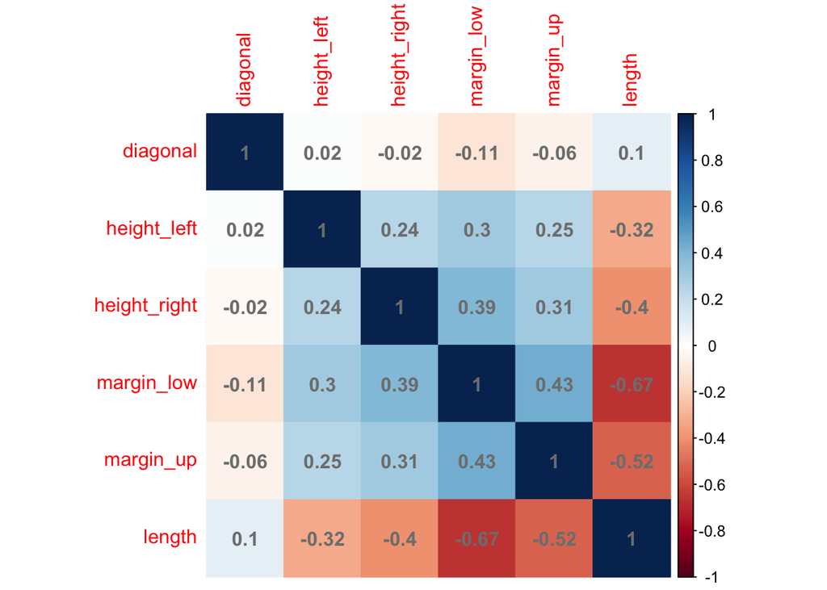

```r
library(corrplot)
corrplot(correlation, method="color", addCoef.col = 'grey50')
```

On fait d’abord vérifier s’il y a des corrélations entre les variables, s’il y en a, on peut appliquer la méthode de régression linéaire multivarié, afin pour remplacer les valeurs manquantes. On peut voir qu’il y a un peu de corrélation entre les variables, mais pas assez forte. On va quand même essayer avec le modèle de régression linéaire multivarié pour voir qu’est ce que cela donne.

## 2.2 - Création du modèle régression linéaire multivarié

On va d’abord séparer les données en données d’entrainement et de test, une fois le modèle prédit bien les données de test, on va ensuite utiliser ce modèle pour déterminer les 37 valeurs manquantes.

```r
library(caret)
set.seed(10)
data_model = subset(data,!is.na(margin_low))
trainIndex <- createDataPartition(data_model$margin_low, p = 0.8, list = FALSE, times = 1)
Xtrain <- data_model[ trainIndex,]
Xtest  <- data_model[-trainIndex,]
```

```r
nrow(Xtrain)
```

```
## [1] 1172
```

```r
nrow(Xtest)
```

```
## [1] 291
```

Nous allons séparer le jeu de données sans les individus qui contiennent des valeurs manquantes, en training set et testing set. J’ai mis la répartition classique 80/20 entre training et testing set, c’est-à-dire que je vais fixer les données d’entrainement à 1172 individus, et les données de test à 291 individus.

```r
reg_margin_low <- lm(margin_low ~ diagonal+height_left+height_right+margin_up+length, data=Xtrain)
summary(reg_margin_low)
```

```
##
## Call:
## lm(formula = margin_low ~ diagonal + height_left + height_right +
##     margin_up + length, data = Xtrain)
##
## Residuals:
##      Min       1Q   Median       3Q      Max
## -1.49072 -0.32009 -0.04175  0.27672  1.98321
##
## Coefficients:
##              Estimate Std. Error t value Pr(>|t|)
## (Intercept)  28.96809   10.93117   2.650 0.008157 **
## diagonal     -0.11217    0.04731  -2.371 0.017899 *
## height_left   0.17186    0.05183   3.316 0.000941 ***
## height_right  0.21909    0.04912   4.460 8.99e-06 ***
## margin_up     0.26817    0.07325   3.661 0.000263 ***
## length       -0.41439    0.02051 -20.202  < 2e-16 ***
## ---
## Signif. codes:  0 '***' 0.001 '**' 0.01 '*' 0.05 '.' 0.1 ' ' 1
##
## Residual standard error: 0.4891 on 1166 degrees of freedom
## Multiple R-squared:  0.4683, Adjusted R-squared:  0.466
## F-statistic: 205.4 on 5 and 1166 DF,  p-value: < 2.2e-16
```

En appliquant le model de régression linéaire, on a un coeffient de détermination à 47 %. Je trouve que le pouvoir de prédire de ce model n’est pas assez forte pour déterminer les valeurs manquantes. On va ajouter la variable ‘is_genuine’ qui distingue les vrais et faux billets pour vois si ce sera mieux.

```r
reg_margin_low = lm(margin_low ~ is_genuine+diagonal+height_left+height_right+margin_up+length, data=Xtrain)
summary(reg_margin_low)
```

```
##
## Call:
## lm(formula = margin_low ~ is_genuine + diagonal + height_left +
##     height_right + margin_up + length, data = Xtrain)
##
## Residuals:
##      Min       1Q   Median       3Q      Max
## -1.35551 -0.26526 -0.00991  0.25818  1.68895
##
## Coefficients:
##                 Estimate Std. Error t value Pr(>|t|)
## (Intercept)    10.482349   9.431959   1.111  0.26664
## is_genuineTrue -1.141698   0.055994 -20.390  < 2e-16 ***
## diagonal       -0.021325   0.040873  -0.522  0.60194
## height_left     0.014646   0.045174   0.324  0.74583
## height_right   -0.009044   0.043649  -0.207  0.83589
## margin_up      -0.211113   0.067160  -3.143  0.00171 **
## length         -0.013221   0.026410  -0.501  0.61674
## ---
## Signif. codes:  0 '***' 0.001 '**' 0.01 '*' 0.05 '.' 0.1 ' ' 1
##
## Residual standard error: 0.4201 on 1165 degrees of freedom
## Multiple R-squared:  0.6081, Adjusted R-squared:  0.6061
## F-statistic: 301.3 on 6 and 1165 DF,  p-value: < 2.2e-16
```

```r
result_test <- predict(reg_margin_low, newdata=Xtest, type='response',interval = "prediction",se.fit = T)
result_test$residual.scale
```

```
## [1] 0.4200575
```

## 2.3 - Remplacement des valeurs manquantes

```r
billets = data
VNan = subset(billets,is.na(margin_low))
nrow(VNan)
```

```
## [1] 37
```

```r
predict(reg_margin_low, newdata=VNan)
```

```
##       73      100      152      198      242      252      285      335
## 4.082642 4.098278 4.116846 4.002100 4.137373 4.139747 4.076998 4.122408
##      411      414      446      482      506      612      655      676
## 4.091717 4.088029 4.132242 4.173665 4.122525 4.070973 4.194371 4.224468
##      711      740      743      781      799      845      846      872
## 4.118038 4.113671 4.074664 4.087559 4.108798 4.131207 4.143112 4.126375
##      896      920      946      947      982     1077     1122     1177
## 4.122556 4.209672 4.125301 4.075249 4.130695 5.249450 5.258517 5.298103
##     1304     1316     1348     1436     1439
## 5.313864 5.193594 5.188108 5.158754 5.242606
```

```r
billets[is.na(billets$margin_low),"margin_low"] <- round(predict(reg_margin_low, newdata=VNan),2)
```

```r
variable = c('diagonal','height_left','height_right','margin_low','margin_up','length')
moyen = aggregate(x=billets[variable], by=list(is_genuine=billets$is_genuine), mean)
moyen
```

```
##   is_genuine diagonal height_left height_right margin_low margin_up   length
## 1      False 171.9012    104.1903     104.1436    5.21628   3.35016 111.6306
## 2       True 171.9871    103.9491     103.8087    4.11616   3.05213 113.2024
```

```r
aggregate(billets$is_genuine, by=list(is_genuine=billets$is_genuine), length)
```

```
##   is_genuine    x
## 1      False  500
## 2       True 1000
```

Notre échantillon contient 1500 billets : 1000 vrais billets et 500 faux.

Portrait-robot du vrai billet :

- Hauteur mesurée à gauche : 103.95 mm,
- Hauteur mesurée à droite : 103.81 mm,
- Marge entre le bord supérieur et le bord de l’image : 3.05 mm,
- Marge entre le bord inférieur et le bord de l’image : 4.12 mm,
- Longueur : 113.2 mm,
- Diagonale : 171.99 mm.

Parmi les variables, il y a de grand différent pour les varibles ‘margin_low’ et ‘length’ entre un vrai et un faux billet.

# 3 - ACP et KMeans

## 3.1 - Analyse ACP

### 3.1.1 - Préparation des données centrées et réduites

```r
library(FactoMineR)
X_scaled = scale(billets[,2:7])
res.pca <- PCA(X_scaled, scale.unit=T, ncp=6, graph = FALSE)
```

```r
library("factoextra")
eig.val <- get_eigenvalue(res.pca)
eig.val
```

```
##       eigenvalue variance.percent cumulative.variance.percent
## Dim.1  2.5924651        43.207751                    43.20775
## Dim.2  1.0174482        16.957469                    60.16522
## Dim.3  0.7811780        13.019633                    73.18485
## Dim.4  0.7095219        11.825366                    85.01022
## Dim.5  0.5799796         9.666326                    94.67654
## Dim.6  0.3194073         5.323455                   100.00000
```

### 3.1.2 - Éboulis des valeurs propres

Cet éboulis indique que l’axe F1 et F2 ont une grande inertie de presque 60%. On va s’intéresser aux axes F1 et F2.

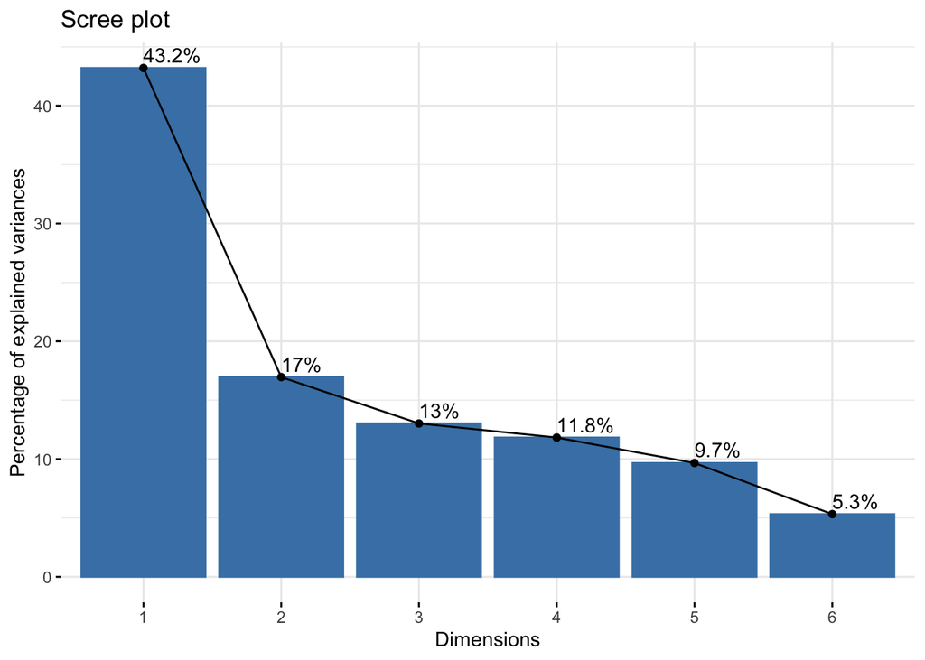

```r
fviz_eig(res.pca, addlabels = TRUE)
```

### 3.1.3 - Cercle de corrélation

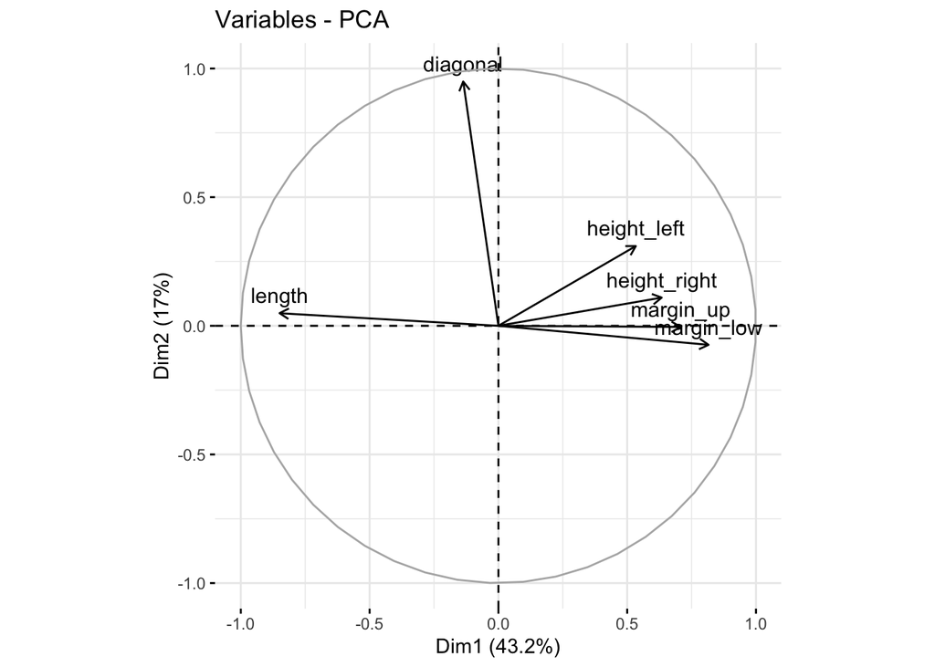

```r
fviz_pca_var(res.pca, col.var = "black")
```

### 3.1.4 - Projection des individus sur les plans factoriels selon le type de billet

On peut observer que la projection des individus sur le premier plan factoriel, qui distingue plutôt bien les vrai et faux billets.

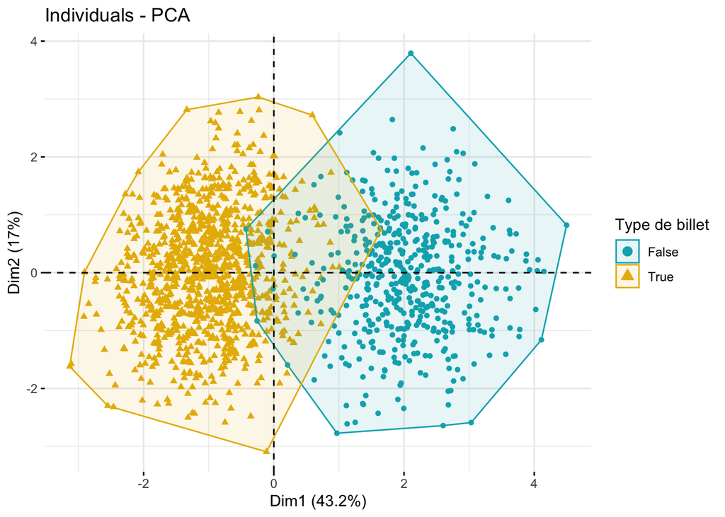

```r
fviz_pca_ind(res.pca,
             geom.ind = "point",
             col.ind = billets$is_genuine,
             palette = c("#00AFBB", "#E7B800"),
             addEllipses = TRUE,
             ellipse.type = "convex",
             legend.title = "Type de billet")
```

## 3.2 - Analyse KMeans

### 3.2.1 - Comparaison de moyen des variables entre clusters et le type de billet

```r
set.seed(123)
km.res = kmeans(X_scaled, 2, nstart = 10)
Clusters = km.res$cluster
```

```r
aggregate(x=billets[variable], by=list(Clusters), mean)
```

```
##   Group.1 diagonal height_left height_right margin_low margin_up   length
## 1       1 171.9877    103.9451     103.8056   4.117809  3.052540 113.1961
## 2       2 171.8992    104.2004     104.1525   5.221815  3.351734 111.6308
```

```r
aggregate(x=billets[variable], by=list(is_genuine=billets$is_genuine), mean)
```

```
##   is_genuine diagonal height_left height_right margin_low margin_up   length
## 1      False 171.9012    104.1903     104.1436    5.21628   3.35016 111.6306
## 2       True 171.9871    103.9491     103.8087    4.11616   3.05213 113.2024
```

Selon ce comparaison de moyen de chaque variable , les groupes créés par KMeans sont très proches de la distinction de vrai et faux billets, donc, cluster 2 correspond à faux billet, et cluster 1 sont de vrai.

### 3.2.2 - Projection des individus sur le premier plan factoriel par clusters

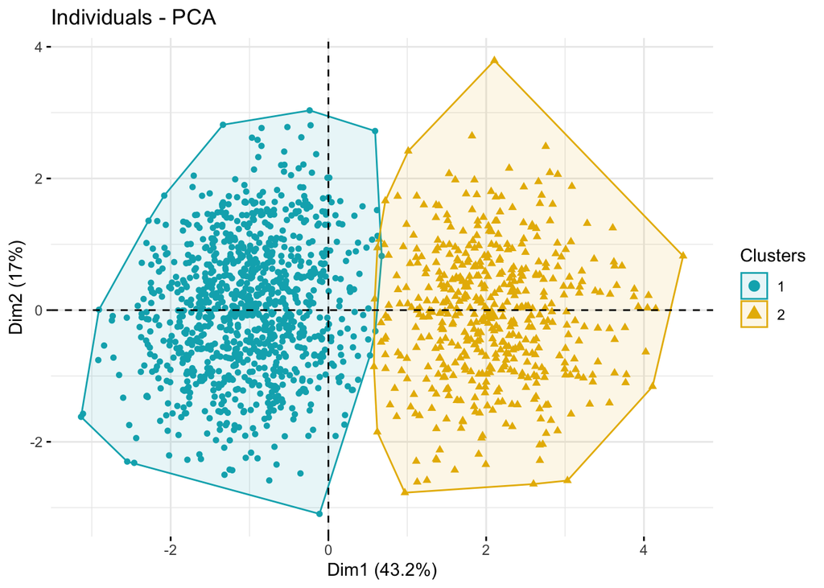

```r
pca_kmeans <- fviz_pca_ind(res.pca, col.ind = factor(Clusters),
             geom = "point", addEllipses = TRUE,
             palette = c("#00AFBB", "#E7B800"),
             ellipse.type = "convex",
             legend.title = "Clusters")
pca_kmeans
```

Visuellement, sur le graphique, les clusters sont aussi très similaire par rapport à la distinction de vrai et faux billets, donc, cluster 2 correspond à faux billet, et cluster 1 est de vrai.

### 3.2.3 - Matrice de confusion Kmeans

```r
kmeans.mat.conf = table(Clusters, billets$is_genuine)
kmeans.mat.conf
```

```
##
## Clusters False True
##        1    14  990
##        2   486   10
```

On fait une analyse des nombres de faux via une matrix de confusion, en comparant les deux clusters avec la distinction original des vrais et faux billets. Donc, ici, nous avons 10 vrais billets détectés comme des faux billets (cluster 2), et 14 faux billets détectés comme des vrais billets (cluster 1). On va ensuite ajouter les données de test pour voir si on peut bien détecter des faux billets à l’aide de KMeans.

### 3.2.4 - Tester les billets inconnus

#### 3.2.5.1 - Importer et combiner les données inconnues avec les données d’origine

```r
b_pro = read.table("Desktop/Openclassrooms/P10_Shibin_YANG/billets_production.csv", sep = ",", dec = ".", header=TRUE, row.names = 7)
b_pro$is_genuine <- NA
billets_plus = rbind(billets, b_pro)
tail(billets_plus, n = 10)
```

```
##      is_genuine diagonal height_left height_right margin_low margin_up length
## 1496      False   171.75      104.38       104.17       4.42      3.09 111.28
## 1497      False   172.19      104.63       104.44       5.27      3.37 110.97
## 1498      False   171.80      104.01       104.12       5.51      3.36 111.95
## 1499      False   172.06      104.28       104.06       5.17      3.46 112.25
## 1500      False   171.47      104.15       103.82       4.63      3.37 112.07
## A_1        <NA>   171.76      104.01       103.54       5.21      3.30 111.42
## A_2        <NA>   171.87      104.17       104.13       6.00      3.31 112.09
## A_3        <NA>   172.00      104.58       104.29       4.99      3.39 111.57
## A_4        <NA>   172.49      104.55       104.34       4.44      3.03 113.20
## A_5        <NA>   171.65      103.63       103.56       3.77      3.16 113.33
```

#### 3.2.5.2 - Préparation des données de test (centrées et réduites)

```r
sup_scaled = scale(billets_plus[,2:7])
ind.sup = sup_scaled[1501:1505,]
ind.sup
```

```
##       diagonal height_left height_right  margin_low   margin_up     length
## A_1 -0.6502494 -0.06691063   -1.1680783  1.09872032  0.64007104 -1.4406417
## A_2 -0.2897739  0.46677866    0.6432366  2.29461494  0.68324930 -0.6729507
## A_3  0.1362425  1.83435748    1.1344407  0.76568638  1.02867535 -1.2687706
## A_4  1.7419969  1.73429074    1.2879419 -0.06689848 -0.52574190  0.5988957
## A_5 -1.0107249 -1.33442271   -1.1066778 -1.08113822  0.03557544  0.7478507
```

```r
ind.sup.pca <- predict(res.pca, newdata = ind.sup)
ind.sup.pca
```

```
## $coord
##         Dim.1      Dim.2      Dim.3       Dim.4      Dim.5      Dim.6
## A_1  1.171402 -0.9133230 -0.1856139 -1.58222528 -0.8086027 -0.2993718
## A_2  2.250959 -0.2634076 -0.1415564 -0.06649874 -0.7950865  1.0546723
## A_3  2.552911  0.6931772  0.8453204  0.13201295  0.3497296 -0.2788292
## A_4  0.353138  2.3497665  1.0606217  1.20006465  0.1194338  0.3475418
## A_5 -1.719290 -1.3667023 -0.4893741 -0.57627756  0.5908850 -0.1251738
##
## $cos2
##          Dim.1      Dim.2       Dim.3        Dim.4       Dim.5       Dim.6
## A_1 0.25004726 0.15200541 0.006278142 0.4561911572 0.119146307 0.016331725
## A_2 0.73377293 0.01004808 0.002901918 0.0006404029 0.091549314 0.161087354
## A_3 0.82187097 0.06059277 0.090110435 0.0021976849 0.015424004 0.009804128
## A_4 0.01494164 0.66154431 0.134781586 0.1725515341 0.001709087 0.014471836
## A_5 0.51316680 0.32427088 0.041575947 0.0576532143 0.060613044 0.002720115
##
## $dist
##      A_1      A_2      A_3      A_4      A_5
## 2.342582 2.627767 2.816008 2.888985 2.400048
```

#### 3.2.5.3 - Projection des individus d’origine par clusters, et les individus inconnus sur le plan factoriel

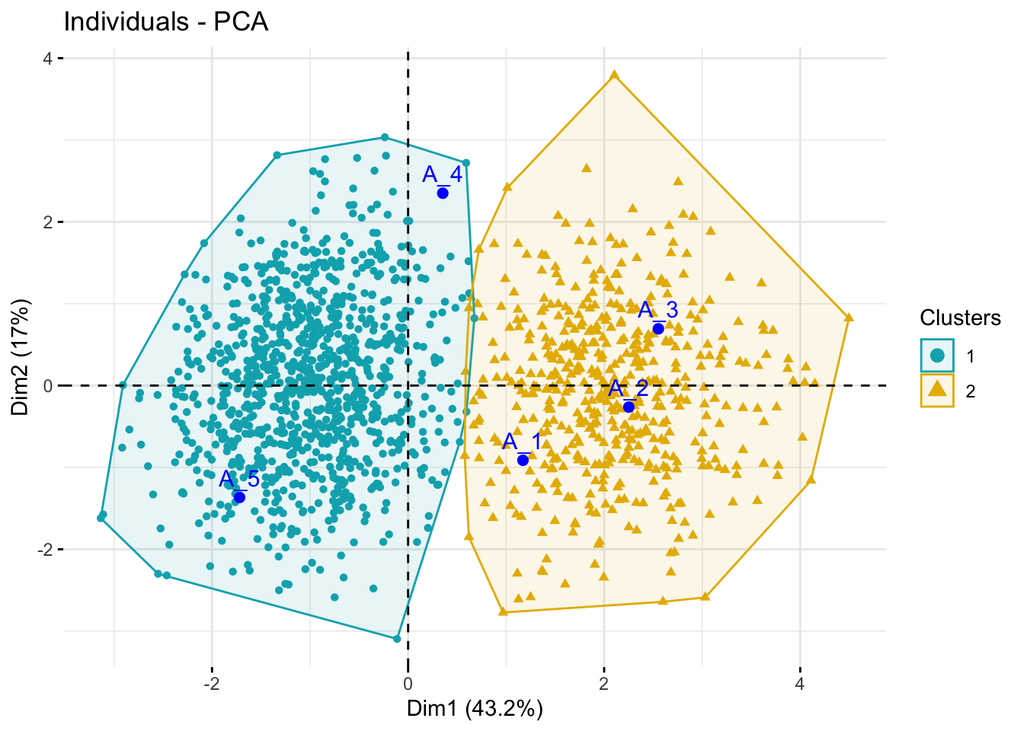

```r
fviz_add(pca_kmeans, ind.sup.pca$coord, color = "blue")
```

On peut quasiment d’être sûr que les billets ‘A_1’, ‘A_2’, ‘A_3’ sont dans le cluster 2, certainement ils sont des faux billets, les billets ‘A_4’, ‘A_5’ sont dans le cluster 1, certainement ils sont des vrais billets. On va essayer de chercher pour chaque individu de test, le plus proche de centoid des deux clusters.

#### 3.2.5.4 - Calcul de la distance entre chaque billet inconnu et le centre des clusters et prédiction par Kmeans

```r
km.res$centers
```

```
##      diagonal height_left height_right margin_low  margin_up     length
## 1  0.09596839  -0.2818519   -0.3523018 -0.5532191 -0.4267813  0.5930423
## 2 -0.19425859   0.5705228    0.7131271  1.1198225  0.8638879 -1.2004325
```

```r
calc_vec2mat_dist = function(x, ref_mat) {
    # compute row-wise vector to vector distance
    apply(ref_mat, 1, function(r) sum((r - x)^2))
}

dist_mat = apply(ind.sup, 1, function(r) calc_vec2mat_dist(r, km.res$centers))
dist_mat
```

```
##        A_1       A_2       A_3       A_4       A_5
## 1 9.271480 12.645406 14.014580  9.710976  3.418196
## 2 4.261423  1.715775  2.041252 12.010813 16.933262
```

On a donc le résultat, les billets ‘A_1’, ‘A_2’, ‘A_3’ sont des faux billets, car ils sont plus proche du centroid de cluster 2, et les billets ‘A_4’, ‘A_5’ sont des vrais, ils sont proche du centroid de cluster 1.

```r
find_clusters <- function(x, centers) {
  # compute squared euclidean distance from each sample to each cluster center
  tmp <- sapply(seq_len(nrow(x)),
                function(i) apply(centers, 1,
                                  function(v) sum((x[i, ]-v)^2)))
  max.col(-t(tmp))  # find index of min distance
}

Centre_data_test = find_clusters(ind.sup, km.res$centers)
verif_data_test = data.frame(rownames(b_pro),Centre_data_test)
colnames(verif_data_test) <- c("Billet","Cluster")
verif_data_test
```

```
##   Billet Cluster
## 1    A_1       2
## 2    A_2       2
## 3    A_3       2
## 4    A_4       1
## 5    A_5       1
```

## 3.3 - Script de modèle de détection Kmeans

On va créer un model pour détecter les billets inconnus, en utilisant la distance minimale entre chaque billets inconnus et les controids des clusters pour réaliser la prédiction.

```r
verif_billets_model_kmeans <- function(csv){
  bills <- read.table(csv, sep = ",", dec = ".", header=TRUE)
  id_bills = bills$id
  bills$is_genuine <- NA
  billets$id <- NA
  bills_plus = rbind(billets, bills)
  test_scaled = scale(bills_plus[variable])
  bills_val = subset(test_scaled[1501:1505,])
  dist = apply(bills_val, 1, function(r) calc_vec2mat_dist(r, km.res$centers))
  predictions = dist[2, ] > dist[1, ]
  for(i in seq_len(nrow(bills))){
     print(paste("Billet", id_bills[i], ":", "c'est un vrai billet =",
            predictions[i]))
}
}
```

```r
verif_billets_model_kmeans("Desktop/Openclassrooms/P10_Shibin_YANG/billets_production.csv")
```

```
## [1] "Billet A_1 : c'est un vrai billet = FALSE"
## [1] "Billet A_2 : c'est un vrai billet = FALSE"
## [1] "Billet A_3 : c'est un vrai billet = FALSE"
## [1] "Billet A_4 : c'est un vrai billet = TRUE"
## [1] "Billet A_5 : c'est un vrai billet = TRUE"
```

Pour être sûr de ce résultat, on va encore essayer les autres méthodes.

# 4 - Régression logistique

## 4.1 - Séparation des données d’entraînement et de test

```r
df_reg_log = billets
# Transformer les données de type caractère "True" et "False" à 1 et 0
df_reg_log$is_genuine <- ifelse(df_reg_log$is_genuine=="True", 1, 0)

set.seed(0)
trainIndex <- createDataPartition(df_reg_log$is_genuine, p = 0.8, list = FALSE, times = 1)

XTrain <- df_reg_log[ trainIndex,]
XTest  <- df_reg_log[-trainIndex,]
```

```r
nrow(XTrain)
```

```
## [1] 1200
```

```r
nrow(XTest)
```

```
## [1] 300
```

Pour appliquer cette méthode, nous allons séparer le jeu de données en training set et testing set. J’ai mis la répartition classique 80/20 entre training et testing set, c’est-à-dire que je vais fixer les données d’entrainement à 1200 individus, et les données de test à 300 individus.

## 4.2 - Création de modèle régression logistique

On va créer le model régression logistique.

```r
reg.log <- glm(is_genuine ~ diagonal+height_left+height_right+margin_low+margin_up+length, data = XTrain, family=binomial)
summary(reg.log)
```

```
##
## Call:
## glm(formula = is_genuine ~ diagonal + height_left + height_right +
##     margin_low + margin_up + length, family = binomial, data = XTrain)
##
## Deviance Residuals:
##     Min       1Q   Median       3Q      Max
## -3.8428  -0.0014   0.0038   0.0218   2.5899
##
## Coefficients:
##              Estimate Std. Error z value Pr(>|z|)
## (Intercept)  -96.2693   267.0741  -0.360   0.7185
## diagonal       0.1216     1.2116   0.100   0.9201
## height_left   -1.8042     1.2566  -1.436   0.1511
## height_right  -2.9467     1.2429  -2.371   0.0177 *
## margin_low    -5.9445     1.0862  -5.473 4.43e-08 ***
## margin_up    -11.6358     2.6025  -4.471 7.78e-06 ***
## length         5.6375     0.9385   6.007 1.89e-09 ***
## ---
## Signif. codes:  0 '***' 0.001 '**' 0.01 '*' 0.05 '.' 0.1 ' ' 1
##
## (Dispersion parameter for binomial family taken to be 1)
##
##     Null deviance: 1533.119  on 1199  degrees of freedom
## Residual deviance:   62.552  on 1193  degrees of freedom
## AIC: 76.552
##
## Number of Fisher Scoring iterations: 10
```

## 4.3 - Coefficient de détermination

Dans une régression linéaire typique, nous utilisons R2 comme moyen d’évaluer dans quelle mesure un modèle s’adapte aux données. Ce nombre varie de 0 à 1, les valeurs les plus élevées indiquant un meilleur ajustement du modèle.

Cependant, il n’y a pas une telle valeur R2 pour la régression logistique. Au lieu de cela, nous pouvons calculer une métrique connue sous le nom de R2 de McFadden, qui va de 0 à un peu moins de 1. Des valeurs proches de 0 indiquent que le modèle n’a aucun pouvoir prédictif.À l’inverse, des valeurs proches de 1 indiquent que le modèle a un fort pouvoir prédictif.

```r
library(pscl)
pR2(reg.log)["McFadden"]
```

```
## fitting null model for pseudo-r2
```

```
##  McFadden
## 0.9591996
```

Le coefficient de détermination R2 = 95.92%.

## 4.4 - Matrice de confusion régression logistique

```r
library(InformationValue)
YTest <- XTest$is_genuine
# Arrondir les résultats de prédiction en nombre entier
Y_predict <- round(predict(reg.log, XTest, type = "response"),0)
# Matrice de confusion
conf_Mat_log = confusionMatrix(YTest, Y_predict)
conf_Mat_log
```

```
##    0   1
## 0 93   0
## 1  3 204
```

En appliquant la méthode de régression logistique avec les données de test, selon la matrice de confusion, nous avons 0 vrais billets détectés comme des faux billets, et 3 faux billets détectés comme des vrais billets.

## 4.5 - Évaluation du modèle avec les données de test

```r
precision(YTest, Y_predict)
```

```
## [1] 0.9855072
```

Nous pouvons également calculer la sensibilité (également appelée «taux de vrais positifs») et la spécificité (également appelée «taux de vrais négatifs») ainsi que l’erreur totale de mauvaise classification (qui nous indique le pourcentage de classifications incorrectes totales):

```r
print(paste("Le taux de vrais positifs = ", sensitivity(YTest, Y_predict)*100,"%", sep=""))
```

```
## [1] "Le taux de vrais positifs = 100%"
```

```r
print(paste("Le taux de vrais négatifs = ", round(specificity(YTest, Y_predict)*100,2),"%", sep=""))
```

```
## [1] "Le taux de vrais négatifs = 96.88%"
```

```r
print(paste("L'erreur totale de mauvaise classification = ", misClassError(YTest, Y_predict)*100,"%", sep=""))
```

```
## [1] "L'erreur totale de mauvaise classification = 1%"
```

## 4.6 - Script de modèle de détection régression logistique

```r
verif_billets_model_reg_log <- function(csv){
  bills <- read.table(csv, sep = ",", dec = ".", header=TRUE)
  id_bills = bills$id
  bills_val = subset(bills[variable])
  predictions = ifelse(round(predict(reg.log, bills_val, type='response'),0) == 1, "Vrai billet", "Faux billet")
  for(i in seq_len(nrow(bills))){
     print(paste("Billet", id_bills[i], "est un", predictions[i]))
}
}
```

On va donc détecter les billets inconnus, on a donc le résultat, les billets ‘A_1’, ‘A_2’, ‘A_3’ sont des faux billets, et les billets ‘A_4’, ‘A_5’ sont des vrais.

```r
verif_billets_model_reg_log("Desktop/Openclassrooms/P10_Shibin_YANG/billets_production.csv")
```

```
## [1] "Billet A_1 est un Faux billet"
## [1] "Billet A_2 est un Faux billet"
## [1] "Billet A_3 est un Faux billet"
## [1] "Billet A_4 est un Vrai billet"
## [1] "Billet A_5 est un Vrai billet"
```

On va essayer encore la méthode KNN pour vérifier si la détection de ce model est correcte.

# 5 - K Nearest Neighbors (K-NN)

## 5.1 - Séparation des données d’entraînement et de test

On va maintenant essayer la méthode K-NN, c’est un algorithme qui peut servir autant pour la classification que pour la régression. Il est surnommé « nearest neighbors » (plus proches voisins, en français) car le principe de ce modèle consiste en effet à choisir les k données les plus proches du point étudié afin d’en prédire sa valeur.

Pour l’appliquer, nous allons séparer le jeu de données en training set et testing set comme précédent. J’ai mis la répartition classique 80/20 entre training et testing set.

```r
set.seed(10)
trainIndex <- createDataPartition(billets$is_genuine, p = 0.8, list = FALSE, times = 1)

X_Train <- billets[ trainIndex,]
X_Test  <- billets[-trainIndex,]
```

```r
nrow(X_Train)
```

```
## [1] 1200
```

```r
nrow(X_Test)
```

```
## [1] 300
```

## 5.2 - Calcul le nombre optimal de K

```r
library(class)
for (i in 1:round(sqrt(dim(X_Train)[1]))){
    model <- knn(train = X_Train[,-1], test = X_Test[,-1],
cl = X_Train$is_genuine, k = i)
    Freq <- table(X_Test[,1], model)
    print(1-sum(diag(Freq))/sum(Freq))
}
```

```
## [1] 0.01333333
## [1] 0.01
## [1] 0.006666667
## [1] 0.006666667
## [1] 0.006666667
## [1] 0.006666667
## [1] 0.006666667
## [1] 0.006666667
## [1] 0.006666667
## [1] 0.006666667
## [1] 0.006666667
## [1] 0.006666667
## [1] 0.006666667
## [1] 0.006666667
## [1] 0.006666667
```

[output cut: 20 more lines]

## 5.3 - Création de modèle 3-NN et la matrice de confusion K-NN

```r
model <- knn(train = X_Train[,-1], test = X_Test[,-1],
cl = X_Train$is_genuine, k = 3)
conf_Mat_knn <- table(X_Test[,1], model)
conf_Mat_knn
```

```
##        model
##         False True
##   False    98    2
##   True      0  200
```

## 5.4 - Évaluation du modèle avec les données de test

Le taux de prédiction d’un billet sera correcte s’éleve aussi à 99%. On calcul le taux précis de prédiction sur les données de test, qui est égale à peu près 99%.

```r
print(paste("Le taux de prédiction correcte sur les données de test = ", round(sum(diag(Freq))/sum(Freq)*100,2),"%", sep=""))
```

```
## [1] "Le taux de prédiction correcte sur les données de test = 98.67%"
```

## 5.5 - Script de modèle de détection K-NN

```r
verif_billets_model_knn <- function(csv){
  bills <- read.table(csv, sep = ",", dec = ".", header=TRUE)
  id_bills = bills$id
  bills_val = subset(bills[variable])
  predictions = knn(train = X_Train[,-1], test = bills_val[,-7],
cl = X_Train$is_genuine, k = 3)
  for(i in seq_len(nrow(bills))){
     print(paste("Billet", id_bills[i], "est un vrai billet =", predictions[i]))
}
}
```

On va donc détecter les billets inconnus, on a donc le même résultat, les billets ‘A_1’, ‘A_2’, ‘A_3’ sont des faux billets, et les billets ‘A_4’, ‘A_5’ sont des vrais.

```r
verif_billets_model_knn("Desktop/Openclassrooms/P10_Shibin_YANG/billets_production.csv")
```

```
## [1] "Billet A_1 est un vrai billet = False"
## [1] "Billet A_2 est un vrai billet = False"
## [1] "Billet A_3 est un vrai billet = False"
## [1] "Billet A_4 est un vrai billet = True"
## [1] "Billet A_5 est un vrai billet = True"
```